[figure not shown]

# Finite Difference Methods

**Kannan Singaravelu**

March, 2022

## Finite Difference Methods

Finite Difference Methods (FDM) are one of the popular numerical methods used in computational finance. FDM are discretizations used for solving differential equations by approximating them with difference equations. It is one of the simplest and the oldest methods to solve differential equations. These techniques were applied to numerical applications as early as 1950s.

FDM are similar in approach to the (binomial) tress. However, instead of discretizing asset prices and the passage of time in a tree structure, it discretizes in a grid - with time and price steps - by calculating the value at every possible grid points.

**Explicit, Implicit and Crank-Nicolson** are the three popular approaches of FDM. The explicit methods are simple to implement, but it does not always converge and largely depends on the size of the time and asset step. Explicit methods are unstable when compared to other two methods. Finite Difference approach is peferred for low dimensional problem, usually upto 4 dimensions.

## Differentiation Using The Grid

The Binomial method contains the diffusion - the volatility - in the tree structure whereas in FDM, the *'tree'* is fixed and we change the parameters to reflect the changing diffusion. We will now define the grid by specifying the time step $\delta t$ and asset step $\delta s$ as

$$S = i \delta s$$

and times

$$t = T - k \delta t$$

*where 0 $\leq$ i $\leq$ I and 0 $\leq$ k $\leq$ K and T is time to expiration and t is time remaining to expirartion*

Here $i$ and $k$ are respective steps in the grid and we can write the value of the option at each grid points as

$$V_{i}^k = (i \delta S, T-k \delta t )$$

## Approximating Greeks

The greeks terms, the Black–Scholes equation can be written as

$$ \frac{\partial V}{\partial t} + \frac{1}{2} \sigma^2 S^2 \frac{\partial^2 V}{\partial S^2} + r S \frac{\partial V}{\partial S} - rV = 0 $$

$$ \Theta + \frac{1}{2} \sigma^2 S^2 \Gamma + r S \Delta - rV = 0 $$

Assume that we know the option value at each grid points, we can extract the derivatives of the option using Taylor series expansion.

### Approximating $\Theta$

We know that the first derivative of option as,

$$ \frac{\partial V}{\partial t} = \lim_{h \to 0} \frac{V(S, t+h) - V(S, t)}{h} $$

We can then approximate the time derivative from our grid using

$$ \frac{\partial V}{\partial t}(S, t) \approx \frac{V_{i}^{k} - V_{i}^{k+1} }{\delta t} $$

### Approximating $\Delta$

From the lecture, we know that the central difference has much lower error when compared to forward and backward differences. Accordingly, we can approximate the first derivative of option with respect to the underlying as

$$ \frac{\partial V}{\partial S}(S, t) \approx \frac{V_{i+1}^{k} - V_{i-1}^{k} }{2 \delta S} $$

### Approximating $\Gamma$

The gamma of the option is the second derivative of option with respective to the underlying and approximating it we have,

$$ \frac{\partial V^2}{\partial S^2} (S, t) \approx \frac{V_{i+1}^{k} - 2 V_{i}^{k} + V_{i-1}^{k} }{\delta S^2} $$

#### Import Required Libraries

```python
# Importing libraries
import pandas as pd
from numpy import *

import cufflinks as cf
cf.set_config_file(offline=True, dimensions=((1000,600)), theme = 'white')

# Set max row and columns to 50
pd.set_option('display.max_rows', 50)
pd.set_option('display.max_columns', 50)
```

## Example

Suppose that we know the value of the option on the below grid points, we can then easily evaluate the greeks as follows

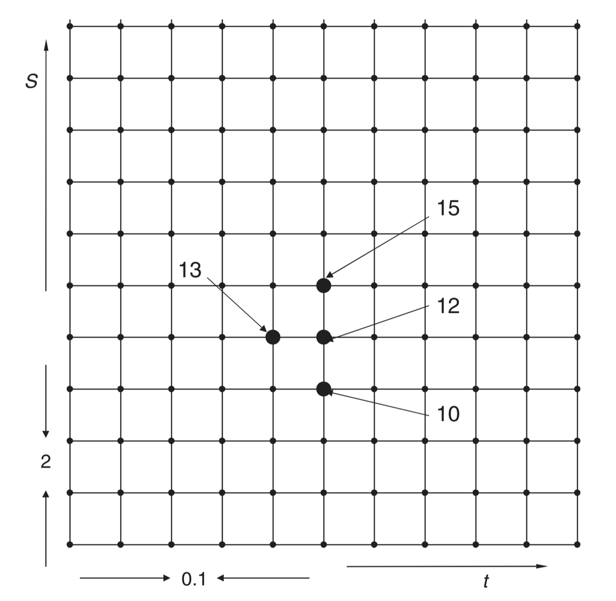

From the grid, we can estimate the

$$\Theta = \frac{12-13}{0.1} = -10$$

$$\Delta = \frac{15-10}{2\times2} = 1.25$$

$$\Gamma = \frac{15-2\times12+10}{2\times2} = 0.25$$

Black Scholes Equation is a relationship between the option value and greeks. If we know the option value at the expiration, we can step back to get the values prior to it such that $V^i_{k+1} = V^i_{k} - \Theta * dt$. This approach is called Explicit Finite Difference Method because the relationship between the option values at current time step is a simple function of the option values at the previous time step.

## Option Pricing Techniques

As with other option pricing techniques Explicit Finite Difference methods are used to price options using what is essentially a three step process.

**Step 1:** Generate the grid by specifying grid points.  
**Step 2:** Specify the final or initial conditions.  
**Step 3:** Use boundary conditions to calculate option values and step back down the grid to fill it.

Note: we will flip the axis for grid generation

### European Option

To price an option, we generate a finite grid of a specified asset and time steps for a given maturity. Next, we specify the initial and boundary conditions to calculate payoff when S and T equals zero. We then step back to fill the grid with newer values derived from the earlier values.

#### Specify Parameters

```python
# Specify parameters for FDM
T = 1                       # time to maturity in years
E = 100                     # strike price
r = 0.05                    # risk free rate
vol = 0.20                  # volatility
Flag = 1                    # Flag 1 for call, -1 for puts
NAS = 20                    # number of asset steps

ds = 2*E/NAS                # asset step size
dt = (0.9/vol**2/NAS**2)    # time steps size, for stability

NTS = int(T/dt)+1            # number of time steps
dt = T/NTS                  # time step
```

#### Step 1

Let's now build the grid with the above input parameters

```python
# Create asset steps i*ds
s = arange(0, (NAS+1)*ds, ds)
s
```

```
array([  0.,  10.,  20.,  30.,  40.,  50.,  60.,  70.,  80.,  90., 100.,
       110., 120., 130., 140., 150., 160., 170., 180., 190., 200.])
```

```python
# Create time steps
t = arange(0, (NTS+1)*dt, dt)
t
```

```
array([0.        , 0.05555556, 0.11111111, 0.16666667, 0.22222222,
       0.27777778, 0.33333333, 0.38888889, 0.44444444, 0.5       ,
       0.55555556, 0.61111111, 0.66666667, 0.72222222, 0.77777778,
       0.83333333, 0.88888889, 0.94444444, 1.        ])
```

```python
# Verify the steps size
s.shape, t.shape
```

```
((21,), (19,))
```

```python
# Initialize the grid with zeros
grid = zeros((len(s), len(t)))

# Subsume the grid points into a dataframe
# with asset price as index and time steps as columns
grid = pd.DataFrame(grid, index=s, columns=around(t,3))
grid
```

|  | 0.000 | 0.056 | 0.111 | 0.167 | 0.222 | 0.278 | 0.333 | 0.389 | 0.444 | 0.500 | 0.556 | 0.611 | 0.667 | 0.722 | 0.778 | 0.833 | 0.889 | 0.944 | 1.000 |
| --- | --- | --- | --- | --- | --- | --- | --- | --- | --- | --- | --- | --- | --- | --- | --- | --- | --- | --- | --- |
| 0.0 | 0.0 | 0.0 | 0.0 | 0.0 | 0.0 | 0.0 | 0.0 | 0.0 | 0.0 | 0.0 | 0.0 | 0.0 | 0.0 | 0.0 | 0.0 | 0.0 | 0.0 | 0.0 | 0.0 |
| 10.0 | 0.0 | 0.0 | 0.0 | 0.0 | 0.0 | 0.0 | 0.0 | 0.0 | 0.0 | 0.0 | 0.0 | 0.0 | 0.0 | 0.0 | 0.0 | 0.0 | 0.0 | 0.0 | 0.0 |
| 20.0 | 0.0 | 0.0 | 0.0 | 0.0 | 0.0 | 0.0 | 0.0 | 0.0 | 0.0 | 0.0 | 0.0 | 0.0 | 0.0 | 0.0 | 0.0 | 0.0 | 0.0 | 0.0 | 0.0 |
| 30.0 | 0.0 | 0.0 | 0.0 | 0.0 | 0.0 | 0.0 | 0.0 | 0.0 | 0.0 | 0.0 | 0.0 | 0.0 | 0.0 | 0.0 | 0.0 | 0.0 | 0.0 | 0.0 | 0.0 |
| 40.0 | 0.0 | 0.0 | 0.0 | 0.0 | 0.0 | 0.0 | 0.0 | 0.0 | 0.0 | 0.0 | 0.0 | 0.0 | 0.0 | 0.0 | 0.0 | 0.0 | 0.0 | 0.0 | 0.0 |
| 50.0 | 0.0 | 0.0 | 0.0 | 0.0 | 0.0 | 0.0 | 0.0 | 0.0 | 0.0 | 0.0 | 0.0 | 0.0 | 0.0 | 0.0 | 0.0 | 0.0 | 0.0 | 0.0 | 0.0 |
| 60.0 | 0.0 | 0.0 | 0.0 | 0.0 | 0.0 | 0.0 | 0.0 | 0.0 | 0.0 | 0.0 | 0.0 | 0.0 | 0.0 | 0.0 | 0.0 | 0.0 | 0.0 | 0.0 | 0.0 |
| 70.0 | 0.0 | 0.0 | 0.0 | 0.0 | 0.0 | 0.0 | 0.0 | 0.0 | 0.0 | 0.0 | 0.0 | 0.0 | 0.0 | 0.0 | 0.0 | 0.0 | 0.0 | 0.0 | 0.0 |
| 80.0 | 0.0 | 0.0 | 0.0 | 0.0 | 0.0 | 0.0 | 0.0 | 0.0 | 0.0 | 0.0 | 0.0 | 0.0 | 0.0 | 0.0 | 0.0 | 0.0 | 0.0 | 0.0 | 0.0 |
| 90.0 | 0.0 | 0.0 | 0.0 | 0.0 | 0.0 | 0.0 | 0.0 | 0.0 | 0.0 | 0.0 | 0.0 | 0.0 | 0.0 | 0.0 | 0.0 | 0.0 | 0.0 | 0.0 | 0.0 |
| 100.0 | 0.0 | 0.0 | 0.0 | 0.0 | 0.0 | 0.0 | 0.0 | 0.0 | 0.0 | 0.0 | 0.0 | 0.0 | 0.0 | 0.0 | 0.0 | 0.0 | 0.0 | 0.0 | 0.0 |
| 110.0 | 0.0 | 0.0 | 0.0 | 0.0 | 0.0 | 0.0 | 0.0 | 0.0 | 0.0 | 0.0 | 0.0 | 0.0 | 0.0 | 0.0 | 0.0 | 0.0 | 0.0 | 0.0 | 0.0 |
| 120.0 | 0.0 | 0.0 | 0.0 | 0.0 | 0.0 | 0.0 | 0.0 | 0.0 | 0.0 | 0.0 | 0.0 | 0.0 | 0.0 | 0.0 | 0.0 | 0.0 | 0.0 | 0.0 | 0.0 |
| 130.0 | 0.0 | 0.0 | 0.0 | 0.0 | 0.0 | 0.0 | 0.0 | 0.0 | 0.0 | 0.0 | 0.0 | 0.0 | 0.0 | 0.0 | 0.0 | 0.0 | 0.0 | 0.0 | 0.0 |
| 140.0 | 0.0 | 0.0 | 0.0 | 0.0 | 0.0 | 0.0 | 0.0 | 0.0 | 0.0 | 0.0 | 0.0 | 0.0 | 0.0 | 0.0 | 0.0 | 0.0 | 0.0 | 0.0 | 0.0 |
| 150.0 | 0.0 | 0.0 | 0.0 | 0.0 | 0.0 | 0.0 | 0.0 | 0.0 | 0.0 | 0.0 | 0.0 | 0.0 | 0.0 | 0.0 | 0.0 | 0.0 | 0.0 | 0.0 | 0.0 |
| 160.0 | 0.0 | 0.0 | 0.0 | 0.0 | 0.0 | 0.0 | 0.0 | 0.0 | 0.0 | 0.0 | 0.0 | 0.0 | 0.0 | 0.0 | 0.0 | 0.0 | 0.0 | 0.0 | 0.0 |
| 170.0 | 0.0 | 0.0 | 0.0 | 0.0 | 0.0 | 0.0 | 0.0 | 0.0 | 0.0 | 0.0 | 0.0 | 0.0 | 0.0 | 0.0 | 0.0 | 0.0 | 0.0 | 0.0 | 0.0 |
| 180.0 | 0.0 | 0.0 | 0.0 | 0.0 | 0.0 | 0.0 | 0.0 | 0.0 | 0.0 | 0.0 | 0.0 | 0.0 | 0.0 | 0.0 | 0.0 | 0.0 | 0.0 | 0.0 | 0.0 |
| 190.0 | 0.0 | 0.0 | 0.0 | 0.0 | 0.0 | 0.0 | 0.0 | 0.0 | 0.0 | 0.0 | 0.0 | 0.0 | 0.0 | 0.0 | 0.0 | 0.0 | 0.0 | 0.0 | 0.0 |
| 200.0 | 0.0 | 0.0 | 0.0 | 0.0 | 0.0 | 0.0 | 0.0 | 0.0 | 0.0 | 0.0 | 0.0 | 0.0 | 0.0 | 0.0 | 0.0 | 0.0 | 0.0 | 0.0 | 0.0 |

#### Step 2

### Final condition and payoffs

$$V_{i}^0 = max(i \delta s - E, 0)$$

```python
# Set Final or Initial condition at Expiration
if Flag==1:
    grid.iloc[:,0] = maximum(s-E,0)
else:
    grid.iloc[:,0] = maximum(E-s,0)
```

```python
# Verify the grid
grid
```

|  | 0.000 | 0.056 | 0.111 | 0.167 | 0.222 | 0.278 | 0.333 | 0.389 | 0.444 | 0.500 | 0.556 | 0.611 | 0.667 | 0.722 | 0.778 | 0.833 | 0.889 | 0.944 | 1.000 |
| --- | --- | --- | --- | --- | --- | --- | --- | --- | --- | --- | --- | --- | --- | --- | --- | --- | --- | --- | --- |
| 0.0 | 0.0 | 0.0 | 0.0 | 0.0 | 0.0 | 0.0 | 0.0 | 0.0 | 0.0 | 0.0 | 0.0 | 0.0 | 0.0 | 0.0 | 0.0 | 0.0 | 0.0 | 0.0 | 0.0 |
| 10.0 | 0.0 | 0.0 | 0.0 | 0.0 | 0.0 | 0.0 | 0.0 | 0.0 | 0.0 | 0.0 | 0.0 | 0.0 | 0.0 | 0.0 | 0.0 | 0.0 | 0.0 | 0.0 | 0.0 |
| 20.0 | 0.0 | 0.0 | 0.0 | 0.0 | 0.0 | 0.0 | 0.0 | 0.0 | 0.0 | 0.0 | 0.0 | 0.0 | 0.0 | 0.0 | 0.0 | 0.0 | 0.0 | 0.0 | 0.0 |
| 30.0 | 0.0 | 0.0 | 0.0 | 0.0 | 0.0 | 0.0 | 0.0 | 0.0 | 0.0 | 0.0 | 0.0 | 0.0 | 0.0 | 0.0 | 0.0 | 0.0 | 0.0 | 0.0 | 0.0 |
| 40.0 | 0.0 | 0.0 | 0.0 | 0.0 | 0.0 | 0.0 | 0.0 | 0.0 | 0.0 | 0.0 | 0.0 | 0.0 | 0.0 | 0.0 | 0.0 | 0.0 | 0.0 | 0.0 | 0.0 |
| 50.0 | 0.0 | 0.0 | 0.0 | 0.0 | 0.0 | 0.0 | 0.0 | 0.0 | 0.0 | 0.0 | 0.0 | 0.0 | 0.0 | 0.0 | 0.0 | 0.0 | 0.0 | 0.0 | 0.0 |
| 60.0 | 0.0 | 0.0 | 0.0 | 0.0 | 0.0 | 0.0 | 0.0 | 0.0 | 0.0 | 0.0 | 0.0 | 0.0 | 0.0 | 0.0 | 0.0 | 0.0 | 0.0 | 0.0 | 0.0 |
| 70.0 | 0.0 | 0.0 | 0.0 | 0.0 | 0.0 | 0.0 | 0.0 | 0.0 | 0.0 | 0.0 | 0.0 | 0.0 | 0.0 | 0.0 | 0.0 | 0.0 | 0.0 | 0.0 | 0.0 |
| 80.0 | 0.0 | 0.0 | 0.0 | 0.0 | 0.0 | 0.0 | 0.0 | 0.0 | 0.0 | 0.0 | 0.0 | 0.0 | 0.0 | 0.0 | 0.0 | 0.0 | 0.0 | 0.0 | 0.0 |
| 90.0 | 0.0 | 0.0 | 0.0 | 0.0 | 0.0 | 0.0 | 0.0 | 0.0 | 0.0 | 0.0 | 0.0 | 0.0 | 0.0 | 0.0 | 0.0 | 0.0 | 0.0 | 0.0 | 0.0 |
| 100.0 | 0.0 | 0.0 | 0.0 | 0.0 | 0.0 | 0.0 | 0.0 | 0.0 | 0.0 | 0.0 | 0.0 | 0.0 | 0.0 | 0.0 | 0.0 | 0.0 | 0.0 | 0.0 | 0.0 |
| 110.0 | 10.0 | 0.0 | 0.0 | 0.0 | 0.0 | 0.0 | 0.0 | 0.0 | 0.0 | 0.0 | 0.0 | 0.0 | 0.0 | 0.0 | 0.0 | 0.0 | 0.0 | 0.0 | 0.0 |
| 120.0 | 20.0 | 0.0 | 0.0 | 0.0 | 0.0 | 0.0 | 0.0 | 0.0 | 0.0 | 0.0 | 0.0 | 0.0 | 0.0 | 0.0 | 0.0 | 0.0 | 0.0 | 0.0 | 0.0 |
| 130.0 | 30.0 | 0.0 | 0.0 | 0.0 | 0.0 | 0.0 | 0.0 | 0.0 | 0.0 | 0.0 | 0.0 | 0.0 | 0.0 | 0.0 | 0.0 | 0.0 | 0.0 | 0.0 | 0.0 |
| 140.0 | 40.0 | 0.0 | 0.0 | 0.0 | 0.0 | 0.0 | 0.0 | 0.0 | 0.0 | 0.0 | 0.0 | 0.0 | 0.0 | 0.0 | 0.0 | 0.0 | 0.0 | 0.0 | 0.0 |
| 150.0 | 50.0 | 0.0 | 0.0 | 0.0 | 0.0 | 0.0 | 0.0 | 0.0 | 0.0 | 0.0 | 0.0 | 0.0 | 0.0 | 0.0 | 0.0 | 0.0 | 0.0 | 0.0 | 0.0 |
| 160.0 | 60.0 | 0.0 | 0.0 | 0.0 | 0.0 | 0.0 | 0.0 | 0.0 | 0.0 | 0.0 | 0.0 | 0.0 | 0.0 | 0.0 | 0.0 | 0.0 | 0.0 | 0.0 | 0.0 |
| 170.0 | 70.0 | 0.0 | 0.0 | 0.0 | 0.0 | 0.0 | 0.0 | 0.0 | 0.0 | 0.0 | 0.0 | 0.0 | 0.0 | 0.0 | 0.0 | 0.0 | 0.0 | 0.0 | 0.0 |
| 180.0 | 80.0 | 0.0 | 0.0 | 0.0 | 0.0 | 0.0 | 0.0 | 0.0 | 0.0 | 0.0 | 0.0 | 0.0 | 0.0 | 0.0 | 0.0 | 0.0 | 0.0 | 0.0 | 0.0 |
| 190.0 | 90.0 | 0.0 | 0.0 | 0.0 | 0.0 | 0.0 | 0.0 | 0.0 | 0.0 | 0.0 | 0.0 | 0.0 | 0.0 | 0.0 | 0.0 | 0.0 | 0.0 | 0.0 | 0.0 |
| 200.0 | 100.0 | 0.0 | 0.0 | 0.0 | 0.0 | 0.0 | 0.0 | 0.0 | 0.0 | 0.0 | 0.0 | 0.0 | 0.0 | 0.0 | 0.0 | 0.0 | 0.0 | 0.0 | 0.0 |

#### Step 3

### Boundary condition at S = 0

$$V_{0}^k = (1 - r \delta t) V_{0}^{k-1}$$

### Boundary condition at S = Infinity

$$V_{i}^k = 2 V_{i-1}^{k} - V_{i-2}^{k}$$

```python
# fill the grid
# k is a counter here = t = ttm

for k in range(1, len(t)):
    for i in range(1, len(s)-1):
        delta = (grid.iloc[i+1,k-1] - grid.iloc[i-1,k-1]) / (2*ds)
        gamma = (grid.iloc[i+1,k-1]-2*grid.iloc[i,k-1]+grid.iloc[i-1,k-1])/(ds**2)
        theta = (-0.5*vol**2*s[i]**2*gamma) - (r*s[i]*delta) + (r*grid.iloc[i,k-1])

        grid.iloc[i,k] = grid.iloc[i,k-1] - (theta*dt)

    # set boundary condition at s=0
    # ds = rsdt + sigma*sdx, when s=0, ds=0
    grid.iloc[0,k] = grid.iloc[0,k-1] * (1-r*dt)

    # set boundary condition at s=smax=infinity
    # gamma = 0, so you can linearly intrepolate or extract the values
    grid.iloc[len(s)-1,k] = 2*grid.iloc[len(s)-2,k] - grid.iloc[len(s)-3,k]

    grid = around(grid,3)
```

```python
# Output the option values
grid
```

|  | 0.000 | 0.056 | 0.111 | 0.167 | 0.222 | 0.278 | 0.333 | 0.389 | 0.444 | 0.500 | 0.556 | 0.611 | 0.667 | 0.722 | 0.778 | 0.833 | 0.889 | 0.944 | 1.000 |
| --- | --- | --- | --- | --- | --- | --- | --- | --- | --- | --- | --- | --- | --- | --- | --- | --- | --- | --- | --- |
| 0.0 | 0.0 | 0.000 | 0.000 | 0.000 | 0.000 | 0.000 | 0.000 | 0.000 | 0.000 | 0.000 | 0.000 | 0.000 | 0.000 | 0.000 | 0.000 | 0.000 | 0.000 | 0.000 | 0.000 |
| 10.0 | 0.0 | 0.000 | 0.000 | 0.000 | 0.000 | 0.000 | 0.000 | 0.000 | 0.000 | 0.000 | 0.000 | 0.000 | 0.000 | 0.000 | 0.000 | 0.000 | 0.000 | 0.000 | 0.000 |
| 20.0 | 0.0 | 0.000 | 0.000 | 0.000 | 0.000 | 0.000 | 0.000 | 0.000 | 0.000 | 0.000 | 0.000 | 0.000 | 0.000 | 0.000 | 0.000 | 0.000 | 0.000 | 0.000 | 0.000 |
| 30.0 | 0.0 | 0.000 | 0.000 | 0.000 | 0.000 | 0.000 | 0.000 | 0.000 | 0.000 | 0.000 | 0.000 | 0.000 | 0.000 | 0.000 | 0.000 | 0.000 | 0.000 | 0.000 | 0.000 |
| 40.0 | 0.0 | 0.000 | 0.000 | 0.000 | 0.000 | 0.000 | 0.000 | 0.000 | 0.000 | 0.000 | 0.000 | 0.000 | 0.000 | 0.000 | 0.000 | 0.000 | 0.000 | 0.000 | 0.000 |
| 50.0 | 0.0 | 0.000 | 0.000 | 0.000 | 0.000 | 0.000 | 0.000 | 0.000 | 0.000 | 0.000 | 0.000 | 0.000 | 0.000 | 0.000 | 0.001 | 0.002 | 0.003 | 0.004 | 0.006 |
| 60.0 | 0.0 | 0.000 | 0.000 | 0.000 | 0.000 | 0.000 | 0.000 | 0.000 | 0.001 | 0.002 | 0.004 | 0.007 | 0.011 | 0.016 | 0.023 | 0.031 | 0.041 | 0.053 | 0.066 |
| 70.0 | 0.0 | 0.000 | 0.000 | 0.000 | 0.001 | 0.003 | 0.008 | 0.016 | 0.028 | 0.045 | 0.067 | 0.094 | 0.126 | 0.164 | 0.207 | 0.255 | 0.308 | 0.366 | 0.429 |
| 80.0 | 0.0 | 0.000 | 0.000 | 0.011 | 0.037 | 0.080 | 0.141 | 0.218 | 0.310 | 0.416 | 0.534 | 0.662 | 0.799 | 0.944 | 1.096 | 1.254 | 1.417 | 1.584 | 1.755 |
| 90.0 | 0.0 | 0.000 | 0.128 | 0.336 | 0.592 | 0.878 | 1.181 | 1.494 | 1.812 | 2.131 | 2.450 | 2.767 | 3.081 | 3.392 | 3.700 | 4.005 | 4.306 | 4.604 | 4.899 |
| 100.0 | 0.0 | 1.250 | 2.254 | 3.093 | 3.819 | 4.466 | 5.054 | 5.599 | 6.109 | 6.593 | 7.055 | 7.498 | 7.925 | 8.339 | 8.741 | 9.133 | 9.515 | 9.889 | 10.255 |
| 110.0 | 10.0 | 10.278 | 10.671 | 11.118 | 11.588 | 12.063 | 12.535 | 13.000 | 13.456 | 13.902 | 14.338 | 14.764 | 15.181 | 15.590 | 15.991 | 16.384 | 16.770 | 17.150 | 17.524 |
| 120.0 | 20.0 | 20.278 | 20.555 | 20.848 | 21.159 | 21.486 | 21.826 | 22.175 | 22.529 | 22.887 | 23.247 | 23.608 | 23.968 | 24.327 | 24.684 | 25.039 | 25.392 | 25.742 | 26.090 |
| 130.0 | 30.0 | 30.278 | 30.555 | 30.831 | 31.109 | 31.392 | 31.680 | 31.973 | 32.272 | 32.575 | 32.882 | 33.192 | 33.505 | 33.819 | 34.135 | 34.451 | 34.768 | 35.085 | 35.402 |
| 140.0 | 40.0 | 40.278 | 40.555 | 40.831 | 41.106 | 41.381 | 41.657 | 41.934 | 42.213 | 42.494 | 42.777 | 43.061 | 43.348 | 43.636 | 43.926 | 44.217 | 44.509 | 44.802 | 45.095 |
| 150.0 | 50.0 | 50.278 | 50.555 | 50.831 | 51.106 | 51.381 | 51.655 | 51.929 | 52.202 | 52.476 | 52.750 | 53.025 | 53.300 | 53.576 | 53.852 | 54.130 | 54.408 | 54.687 | 54.966 |
| 160.0 | 60.0 | 60.278 | 60.555 | 60.831 | 61.106 | 61.381 | 61.655 | 61.928 | 62.201 | 62.473 | 62.744 | 63.015 | 63.286 | 63.557 | 63.828 | 64.099 | 64.371 | 64.642 | 64.914 |
| 170.0 | 70.0 | 70.278 | 70.555 | 70.831 | 71.106 | 71.381 | 71.655 | 71.928 | 72.200 | 72.472 | 72.743 | 73.013 | 73.283 | 73.552 | 73.821 | 74.090 | 74.358 | 74.626 | 74.894 |
| 180.0 | 80.0 | 80.278 | 80.555 | 80.831 | 81.106 | 81.381 | 81.655 | 81.928 | 82.200 | 82.472 | 82.743 | 83.013 | 83.282 | 83.551 | 83.819 | 84.086 | 84.354 | 84.620 | 84.886 |
| 190.0 | 90.0 | 90.278 | 90.555 | 90.831 | 91.106 | 91.381 | 91.655 | 91.928 | 92.200 | 92.472 | 92.743 | 93.013 | 93.282 | 93.551 | 93.818 | 94.086 | 94.352 | 94.618 | 94.882 |
| 200.0 | 100.0 | 100.278 | 100.555 | 100.831 | 101.106 | 101.381 | 101.655 | 101.928 | 102.200 | 102.472 | 102.743 | 103.013 | 103.282 | 103.550 | 103.818 | 104.085 | 104.350 | 104.615 | 104.879 |

### Visualize the payoff

```python
# Plot Call Option Payoff
grid.iplot(kind='surface', title='Call Option Values by FDM')
```

[interactive chart not shown]

## Bilinear Interpolation

We have generated the grid and filled it with the possible option values. However, if we have to estimate option value or its derivatives on the mesh points, how can we estimate the value at points in between? The simplest way is to do a two-dimensional interpolation method called **Bilinear Interpolation**.

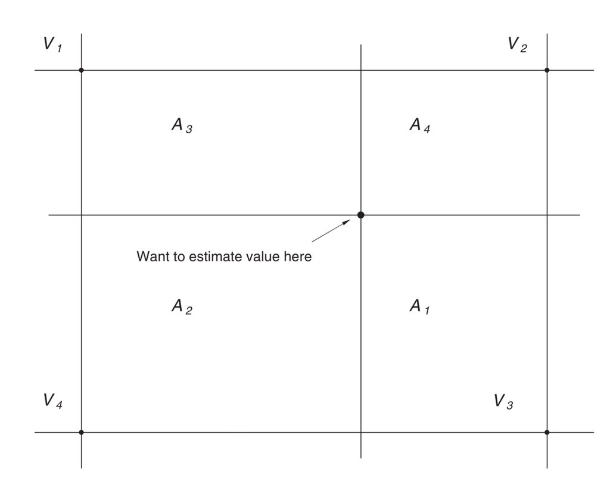

The option value can be estimated using the values from the nearest neighbouring values. Assume $V_1, V_2, V_3 \space and \space V_4$ are the option values from the nearest neighbour and $A_1, A_2, A_3 \space and \space A_4$ are the areas of the rectanges made by the four corners and the interior points, we can approximate the option value at the interior points as

$$\frac{\sum_{i=1}^4 A_iV_i}{\sum_{i=1}^4 A_i}$$

```python
# col1
grid.columns[grid.columns<0.25][-1]
```

```
0.222
```

```python
# col2
grid.columns[grid.columns>=0.25][0]
```

```
0.278
```

```python
# define bilinear interp function
def bilinear_interpolation(asset_price,ttm,df):

    # find relevant row and columns
    col1= df.columns[df.columns<ttm][-1]
    col2 = df.columns[df.columns>=ttm][0]
    row1 = df.index[df.index<asset_price][-1]
    row2 = df.index[df.index>=asset_price][0]

    # define points and areas
    # V1, V2, V3, V4
    V = [df.loc[row1, col1], df.loc[row1, col2],
        df.loc[row2,col2], df.loc[row2, col1]]

    # A1, A2, A3, A4
    A = [(row2-asset_price)*(col2-ttm),
        (row2-asset_price)*(ttm-col1),
        (asset_price-row1)*(ttm-col1),
        (asset_price-row1)*(col2-ttm)
    ]

    # interpolate the values
    return sum(array(A)*array(V)) / sum(array(A))
```

```python
# Option value, approximated
bilinear_interpolation(105,0.25,grid)
```

```
7.983999999999998
```

```python
bilinear_interpolation(115,0.3,grid)
```

```
16.9369
```

## User Defined Function

Let's subsume above grid calculation into a function for ease of use.

```python
def efdm_grid(Strike, Volatility, Rate, TTM, NAS, Flag=1):

    # Specify Flag as 1 for calls and -1 for puts

    ds = 2*Strike/NAS                   # asset step size
    dt = 0.9/Volatility**2/NAS**2       # for stability

    NTS = int(TTM / dt) + 1             # time step size, alternatively use fixed size 10 on stability issue
    dt = TTM/NTS                        # time step

    s = arange(0,(NAS+1)*ds,ds)
    t = TTM-arange(NTS*dt,-dt,-dt)

    # Initialize the grid with zeros
    grid = zeros((len(s),len(t)))
    grid = pd.DataFrame(grid, index=s, columns=around(t,2))

    # Set boundary condition at Expiration
    grid.iloc[:,0] = abs(maximum(Flag * (s - Strike), 0))

    for k in range(1, len(t)):
        for i in range(1,len(s)-1):
            delta = (grid.iloc[i+1,k-1] - grid.iloc[i-1,k-1]) / (2*ds)
            gamma = (grid.iloc[i+1,k-1]-2*grid.iloc[i,k-1]+grid.iloc[i-1,k-1]) / (ds**2)
            theta = (-0.5* vol**2 * s[i]**2 * gamma) - (r*s[i]*delta) + (r*grid.iloc[i,k-1])

            grid.iloc[i,k] = grid.iloc[i,k-1] - dt*theta

        # Set boundary condition at S = 0
        grid.iloc[0,k] = grid.iloc[0,k-1] * (1-r*dt)

        # Set boundary condition at S = infinity
        grid.iloc[len(s)-1,k] = abs(2*(grid.iloc[len(s)-2,k]) - grid.iloc[len(s)-3,k])

    # round grid values to 4 decimals
    return around(grid,2)
```

```python
# put option
fdm_puts = efdm_grid(100,0.2,0.05,1,20,Flag=-1)
fdm_puts
```

|  | 0.00 | 0.06 | 0.11 | 0.17 | 0.22 | 0.28 | 0.33 | 0.39 | 0.44 | 0.50 | 0.56 | 0.61 | 0.67 | 0.72 | 0.78 | 0.83 | 0.89 | 0.94 | 1.00 |
| --- | --- | --- | --- | --- | --- | --- | --- | --- | --- | --- | --- | --- | --- | --- | --- | --- | --- | --- | --- |
| 0.0 | 100.0 | 99.72 | 99.45 | 99.17 | 98.89 | 98.62 | 98.34 | 98.07 | 97.80 | 97.53 | 97.26 | 96.99 | 96.72 | 96.45 | 96.18 | 95.91 | 95.65 | 95.38 | 95.12 |
| 10.0 | 90.0 | 89.72 | 89.45 | 89.17 | 88.89 | 88.62 | 88.34 | 88.07 | 87.80 | 87.53 | 87.26 | 86.99 | 86.72 | 86.45 | 86.18 | 85.91 | 85.65 | 85.38 | 85.12 |
| 20.0 | 80.0 | 79.72 | 79.45 | 79.17 | 78.89 | 78.62 | 78.34 | 78.07 | 77.80 | 77.53 | 77.26 | 76.99 | 76.72 | 76.45 | 76.18 | 75.91 | 75.65 | 75.38 | 75.12 |
| 30.0 | 70.0 | 69.72 | 69.45 | 69.17 | 68.89 | 68.62 | 68.34 | 68.07 | 67.80 | 67.53 | 67.26 | 66.99 | 66.72 | 66.45 | 66.18 | 65.91 | 65.65 | 65.38 | 65.12 |
| 40.0 | 60.0 | 59.72 | 59.45 | 59.17 | 58.89 | 58.62 | 58.34 | 58.07 | 57.80 | 57.53 | 57.26 | 56.99 | 56.72 | 56.45 | 56.18 | 55.91 | 55.65 | 55.38 | 55.12 |
| 50.0 | 50.0 | 49.72 | 49.45 | 49.17 | 48.89 | 48.62 | 48.34 | 48.07 | 47.80 | 47.53 | 47.26 | 46.99 | 46.72 | 46.45 | 46.18 | 45.92 | 45.65 | 45.39 | 45.12 |
| 60.0 | 40.0 | 39.72 | 39.45 | 39.17 | 38.89 | 38.62 | 38.35 | 38.07 | 37.80 | 37.53 | 37.26 | 36.99 | 36.73 | 36.46 | 36.20 | 35.94 | 35.69 | 35.43 | 35.18 |
| 70.0 | 30.0 | 29.72 | 29.45 | 29.17 | 28.89 | 28.62 | 28.35 | 28.09 | 27.83 | 27.57 | 27.32 | 27.08 | 26.84 | 26.61 | 26.39 | 26.17 | 25.96 | 25.75 | 25.55 |
| 80.0 | 20.0 | 19.72 | 19.45 | 19.18 | 18.93 | 18.70 | 18.49 | 18.29 | 18.11 | 17.94 | 17.79 | 17.65 | 17.52 | 17.39 | 17.28 | 17.17 | 17.06 | 16.96 | 16.87 |
| 90.0 | 10.0 | 9.72 | 9.57 | 9.50 | 9.49 | 9.50 | 9.53 | 9.57 | 9.61 | 9.66 | 9.71 | 9.75 | 9.80 | 9.84 | 9.88 | 9.92 | 9.95 | 9.98 | 10.01 |
| 100.0 | 0.0 | 0.97 | 1.70 | 2.26 | 2.71 | 3.08 | 3.40 | 3.67 | 3.91 | 4.12 | 4.31 | 4.48 | 4.64 | 4.79 | 4.92 | 5.05 | 5.16 | 5.27 | 5.37 |
| 110.0 | 0.0 | 0.00 | 0.12 | 0.29 | 0.48 | 0.68 | 0.88 | 1.07 | 1.25 | 1.43 | 1.59 | 1.75 | 1.90 | 2.04 | 2.17 | 2.30 | 2.42 | 2.53 | 2.64 |
| 120.0 | 0.0 | 0.00 | 0.00 | 0.02 | 0.05 | 0.10 | 0.17 | 0.25 | 0.33 | 0.41 | 0.50 | 0.59 | 0.68 | 0.77 | 0.86 | 0.95 | 1.04 | 1.12 | 1.21 |
| 130.0 | 0.0 | 0.00 | 0.00 | 0.00 | 0.00 | 0.01 | 0.02 | 0.04 | 0.07 | 0.10 | 0.14 | 0.18 | 0.22 | 0.27 | 0.31 | 0.36 | 0.41 | 0.47 | 0.52 |
| 140.0 | 0.0 | 0.00 | 0.00 | 0.00 | 0.00 | 0.00 | 0.00 | 0.01 | 0.01 | 0.02 | 0.03 | 0.05 | 0.06 | 0.08 | 0.11 | 0.13 | 0.16 | 0.18 | 0.21 |
| 150.0 | 0.0 | 0.00 | 0.00 | 0.00 | 0.00 | 0.00 | 0.00 | 0.00 | 0.00 | 0.00 | 0.01 | 0.01 | 0.02 | 0.02 | 0.03 | 0.04 | 0.06 | 0.07 | 0.08 |
| 160.0 | 0.0 | 0.00 | 0.00 | 0.00 | 0.00 | 0.00 | 0.00 | 0.00 | 0.00 | 0.00 | 0.00 | 0.00 | 0.00 | 0.01 | 0.01 | 0.01 | 0.02 | 0.02 | 0.03 |
| 170.0 | 0.0 | 0.00 | 0.00 | 0.00 | 0.00 | 0.00 | 0.00 | 0.00 | 0.00 | 0.00 | 0.00 | 0.00 | 0.00 | 0.00 | 0.00 | 0.00 | 0.01 | 0.01 | 0.01 |
| 180.0 | 0.0 | 0.00 | 0.00 | 0.00 | 0.00 | 0.00 | 0.00 | 0.00 | 0.00 | 0.00 | 0.00 | 0.00 | 0.00 | 0.00 | 0.00 | 0.00 | 0.00 | 0.00 | 0.00 |
| 190.0 | 0.0 | 0.00 | 0.00 | 0.00 | 0.00 | 0.00 | 0.00 | 0.00 | 0.00 | 0.00 | 0.00 | 0.00 | 0.00 | 0.00 | 0.00 | 0.00 | 0.00 | 0.00 | 0.00 |
| 200.0 | 0.0 | 0.00 | 0.00 | 0.00 | 0.00 | 0.00 | 0.00 | 0.00 | 0.00 | 0.00 | 0.00 | 0.00 | 0.00 | 0.00 | 0.00 | 0.00 | 0.00 | 0.00 | 0.00 |

```python
# Visualize the plot for put option
fdm_puts.iplot(kind='surface')
```

[interactive chart not shown]

## Convergence Analysis

Let's now compare option pricing for various asset steps (NAS) with black scholes price.

```python
nas_list = [10,20,30,40,50,60]
fdmoption = []

for i in nas_list:
    fdmoption.append(efdm_grid(100,0.2,0.05,1,i).loc[100,1])

fdmoption
```

```
[9.51, 10.26, 10.37, 10.4, 10.42, 10.43]
```

```python
# Call black scholes class
from src.blackscholes import BS

# instantiate the object
option = BS(100,100,0.05,1,0.20)
bsoption = round(option.callPrice,2)
bsoption = bsoption.repeat(len(nas_list))

bsoption
```

```
array([10.45, 10.45, 10.45, 10.45, 10.45, 10.45])
```

```python
# Subsume into dataframe
df = pd.DataFrame(list(zip(bsoption,fdmoption)), columns=['BS', 'FDM'], index=nas_list)
df['dev'] = df['FDM'] - df['BS']
df['% dev'] = round(df['dev'] / df['BS']*100,2)

# output
print('BS-FDM Convergence over NAS')
df
```

```
BS-FDM Convergence over NAS
```

|  | BS | FDM | dev | % dev |
| --- | --- | --- | --- | --- |
| 10 | 10.45 | 9.51 | -0.94 | -9.00 |
| 20 | 10.45 | 10.26 | -0.19 | -1.82 |
| 30 | 10.45 | 10.37 | -0.08 | -0.77 |
| 40 | 10.45 | 10.40 | -0.05 | -0.48 |
| 50 | 10.45 | 10.42 | -0.03 | -0.29 |
| 60 | 10.45 | 10.43 | -0.02 | -0.19 |

## References

- [Python Resources](https://urldefense.com/v3/__https://github.com/kannansingaravelu/PythonResources__;!!KGvANbslH1YjwA!6CNTCdWAeRpadnnfAS1azg2xii0K86QAk22jDzuc4NdVG0DgbuX5DNJ_PnTHXLHuN5h1Usaci71h7RRIcMRnGd4-cqLormTrhQPyrQ$)
- Paul Wilmott (2007), Paul Wilmott introduces Quantitative Finance

[Kannan Singaravelu](https://urldefense.com/v3/__http://twitter.com/kannansi__;!!KGvANbslH1YjwA!6CNTCdWAeRpadnnfAS1azg2xii0K86QAk22jDzuc4NdVG0DgbuX5DNJ_PnTHXLHuN5h1Usaci71h7RRIcMRnGd4-cqLormSeQ2QAeA$) | [GitHub](https://urldefense.com/v3/__https://github.com/kannansingaravelu__;!!KGvANbslH1YjwA!6CNTCdWAeRpadnnfAS1azg2xii0K86QAk22jDzuc4NdVG0DgbuX5DNJ_PnTHXLHuN5h1Usaci71h7RRIcMRnGd4-cqLormSpBTAoUw$)

March, 2022